# The ggchangepoint Feature Tour: A Complete Map of the Package Surface

Youzhi Yu University of Chicago

# Abstract

**ggchangepoint** provides a unified, tidy, `ggplot2`-native interface to changepoint detection in R: one dispatcher (`cpt_detect()`) covering 50 methods across six methodological families, one result class (`ggcpt`) with a stable tidy contract, and one visualisation entry point (`autoplot()`) that draws everything a method reports, including confidence intervals and posterior probabilities (Wickham 2016; Robinson 2017). This vignette is the *feature tour*: it visits **every exported function** in the package at the point where it belongs in the workflow, so a reader can map the full surface in one sitting.

Six companion vignettes go deeper: `vignette("introduction")` develops the methodology, `vignette("comparison")` treats method comparison and evaluation, `vignette("inference")` covers confidence intervals, significance regions, selecting the number of changepoints and the diagnostic displays, `vignette("supervised")` covers labelled regions and learned penalties, `vignette("extending")` shows how to bring an external detector into the same grammar, and `vignette("monitoring")` covers sequential detection on a stream and its detection-delay accounting.

> **New in 0.5.0.** Nineteen further methods; a time index that survives the round trip (`cpt_detect(x, index = dates)` and `ts`/`xts`/`zoo`/ `tsibble` input); significance regions and the `cpt_confint()` / `cpt_test()` inference pair; `cpt_select()` for the number of changepoints; influence, sensitivity, statistic, solution-path and scale-space diagnostics; supervised detection; consensus and method recommendation; event annotation and reports; benchmarking; sequential monitoring; power analysis; and `as_ggcpt()` / `cpt_register_method()` for detectors this package does not wrap. Each has its own section below or its own vignette.

```r
set.seed(2026)
x <- c(rnorm(100, 0, 1), rnorm(100, 6, 1))    # one mean shift at t = 100
x3 <- c(rnorm(100), rnorm(100, 4), rnorm(100, 1))  # shifts at 100, 200
```

# The result object and its methods

Every detector returns a `ggcpt` object: a list carrying the tidy `changepoints` tibble (`cp` = last index of the left segment, `cp_value` = series value there, plus any method-specific columns), a `segments` table, the `data`, the raw engine `fit`, and metadata (method, `change_in`, penalty, convention, runtime). `new_ggcpt()` is the low-level constructor and `is_ggcpt()` the class test; most users never call either directly.

```r
res <- cpt_detect(x, method = "pelt", change_in = "mean")
is_ggcpt(res)
```

```
#> [1] TRUE
```

```r
print(res)
```

```
#> ggcpt (changepoint detection result)
#>   Method:             pelt
#>   Change in:          mean
#>   Changepoints found: 1
#>   CP convention:      left
#>   Penalty:            MBIC
#>   Series length:      200
#>
#> Changepoints:
#> # A tibble: 1 × 2
#>      cp cp_value
#>   <int>    <dbl>
#> 1   100    0.369
```

```r
manual <- new_ggcpt(
  changepoints = tibble::tibble(cp = 100L, cp_value = x[100]),
  data = tibble::tibble(index = seq_along(x), value = x),
  method = "manual"
)
is_ggcpt(manual)
```

```
#> [1] TRUE
```

The `broom` verbs give one row per changepoint (`tidy()`), a one-row model summary (`glance()`), and the data augmented with segment ids, fitted levels, residuals, and a changepoint flag (`augment()`):

```r
tidy(res)
```

```
#> # A tibble: 1 × 2
#>      cp cp_value
#>   <int>    <dbl>
#> 1   100    0.369
```

```r
glance(res)
```

```
#> # A tibble: 1 × 9
#>       n n_changepoints method change_in penalty_type penalty_value cp_convention
#>   <int>          <int> <chr>  <chr>     <chr>                <dbl> <chr>
#> 1   200              1 pelt   mean      MBIC                    NA left
#> # ℹ 2 more variables: total_cost <dbl>, runtime <dbl>
```

```r
head(augment(res))
```

```
#> # A tibble: 6 × 6
#>   index   value seg_id .fitted  .resid is_changepoint
#>   <int>   <dbl>  <int>   <dbl>   <dbl> <lgl>
#> 1     1  0.521       1 -0.0980  0.619  FALSE
#> 2     2 -1.08        1 -0.0980 -0.982  FALSE
#> 3     3  0.139       1 -0.0980  0.237  FALSE
#> 4     4 -0.0847      1 -0.0980  0.0133 FALSE
#> 5     5 -0.667       1 -0.0980 -0.569  FALSE
#> 6     6 -2.52        1 -0.0980 -2.42   FALSE
```

The remaining S3 surface: a human-readable digest, tibble/data-frame coercion, a one-line format, and a base-`plot()` fallback that delegates to `autoplot()`.

```r
summary(res)
```

```
#> ggcpt Summary
#>   Method:             pelt
#>   Change in:          mean
#>   Changepoints found: 1
#>   CP convention:      left
#>   Series length:      200
#>   Penalty:            MBIC
#>   Runtime (seconds):  0.009
#>
#> Segments:
#> # A tibble: 2 × 5
#>   seg_id start   end     n param_estimate
#>    <int> <int> <int> <int>          <dbl>
#> 1      1     1   100   100        -0.0980
#> 2      2   101   200   100         6.12
#>
#> Changepoints:
#> # A tibble: 1 × 2
#>      cp cp_value
#>   <int>    <dbl>
#> 1   100    0.369
```

```r
as_tibble(res)
```

```
#> # A tibble: 1 × 2
#>      cp cp_value
#>   <int>    <dbl>
#> 1   100    0.369
```

```r
head(as.data.frame(res))
```

```
#>    cp  cp_value
#> 1 100 0.3694259
```

```r
format(res)
```

```
#> [1] "ggcpt [pelt] 1 changepoint(s) on 200 observations"
```

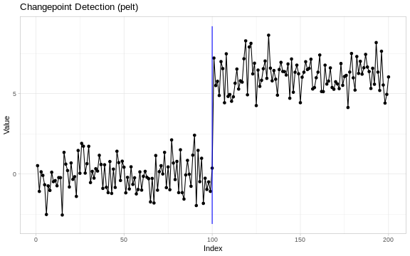

```r
plot(res)
```

# Unified detection

`cpt_detect()` is the recommended entry point: pick a `method`, say what the change is in (`change_in` = `"mean"`, `"var"`, `"meanvar"`, `"slope"`, `"distribution"`, `"covariance"`, `"network"`, `"regression"` or `"seasonality"`, the values `cpt_methods()` lists in its `supports` column), and optionally set a `penalty`. Incompatible `method`/`change_in` combinations error; they are never silently substituted.

```r
cpt_detect(x, method = "binseg", change_in = "mean")
```

```
#> ggcpt (changepoint detection result)
#>   Method:             binseg
#>   Change in:          mean
#>   Changepoints found: 1
#>   CP convention:      left
#>   Penalty:            MBIC
#>   Series length:      200
#>
#> Changepoints:
#> # A tibble: 1 × 2
#>      cp cp_value
#>   <int>    <dbl>
#> 1   100    0.369
```

Anything else in `...` reaches the underlying wrapper, and takes precedence over the value the dispatcher would otherwise derive from `change_in`. Here the NOT contrast is set directly rather than inherited:

```r
tidy(cpt_detect(x, method = "not", contrast = "pcwsLinMean"))
```

```
#> # A tibble: 1 × 2
#>      cp cp_value
#>   <int>    <dbl>
#> 1   100    0.369
```

`cpt_methods()` is the live capability table: every method the package knows, its engine package, what it can detect, and whether the engine is installed. Five rows carry status `"planned"` rather than `"available"`: their engines (`gfpop`, `robseg`, `FOCuS`, `hdbinseg`, `changeforest`) are not on CRAN, so they are documented as future work and are *not* wired to `cpt_detect()`.

```r
print(cpt_methods(), n = Inf)
```

```
#> # A tibble: 55 × 15
#>    method       change_in    engine status installed target_release multivariate
#>    <chr>        <chr>        <chr>  <chr>  <lgl>     <chr>          <lgl>
#>  1 pelt         mean, var, … chang… avail… TRUE      <NA>           FALSE
#>  2 binseg       mean, var, … chang… avail… TRUE      <NA>           FALSE
#>  3 segneigh     mean, var, … chang… avail… TRUE      <NA>           FALSE
#>  4 amoc         mean, var, … chang… avail… TRUE      <NA>           FALSE
#>  5 np           distribution chang… avail… TRUE      <NA>           FALSE
#>  6 ecp          distributio… ecp    avail… TRUE      <NA>           TRUE
#>  7 fpop         mean         fpop   avail… TRUE      <NA>           FALSE
#>  8 wbs          mean         wbs    avail… TRUE      <NA>           FALSE
#>  9 wbs2         mean         break… avail… TRUE      <NA>           FALSE
#> 10 not          mean, var, … not    avail… TRUE      <NA>           FALSE
#> 11 mosum        mean         mosum  avail… TRUE      <NA>           FALSE
#> 12 idetect      mean         IDete… avail… TRUE      <NA>           FALSE
```

[output cut: 45 more lines]

`cpt_penalty()` constructs standard penalty values for the engines that take numeric penalties; see its help for the per-engine penalty semantics.

```r
cpt_penalty("BIC", n = 200)
```

```
#> [1] 5.298317
```

```r
cpt_penalty("MBIC", n = 200)
```

```
#> [1] 10.59663
```

```r
cpt_penalty("Manual", value = 10)
```

```
#> [1] 10
```

# Engine wrappers

Each engine also has a direct wrapper exposing its native arguments. Every wrapper from 0.2.0 onwards returns a `ggcpt` object; only the two original wrappers below predate the class and still return a bare tibble.

## The classical core (0.1.0)

`cpt_wrapper()` and `ecp_wrapper()` are the original interface to the *changepoint*/*changepoint.np* (Killick, Fearnhead, and Eckley 2012; Killick and Eckley 2014; Haynes, Fearnhead, and Eckley 2017) and *ecp* (Matteson and James 2014; James and Matteson 2014) engines; they return bare tibbles for backward compatibility.

```r
cpt_wrapper(x, change_in = "mean", cp_method = "PELT")
```

```
#> # A tibble: 1 × 2
#>      cp cp_value
#>   <int>    <dbl>
#> 1   100    0.369
```

```r
ecp_wrapper(x, algorithm = "divisive", seed = 1)
```

```
#> # A tibble: 1 × 2
#>      cp cp_value
#>   <dbl>    <dbl>
#> 1   101     7.22
```

## The search and pruning wave (0.2.0)

Seven multiscale, randomised, and functional-pruning engines (Fryzlewicz 2014, 2020, 2018; Baranowski, Chen, and Fryzlewicz 2019; Eichinger and Kirch 2018; Anastasiou and Fryzlewicz 2022; Maidstone et al. 2017), one call each:

```r
fpop_wrapper(x, penalty = 2 * log(length(x)))
```

```
#> ggcpt (changepoint detection result)
#>   Method:             fpop
#>   Change in:          mean
#>   Changepoints found: 1
#>   CP convention:      left
#>   Penalty:            Manual = 10.597
#>   Series length:      200
#>
#> Changepoints:
#> # A tibble: 1 × 2
#>      cp cp_value
#>   <int>    <dbl>
#> 1   100    0.369
```

```r
wbs_wrapper(x, n_intervals = 2000, seed = 1)
```

```
#> ggcpt (changepoint detection result)
#>   Method:             wbs
#>   Change in:          mean
#>   Changepoints found: 1
#>   CP convention:      left
#>   Penalty:            sSIC
#>   Series length:      200
#>
#> Changepoints:
#> # A tibble: 1 × 2
#>      cp cp_value
#>   <int>    <dbl>
#> 1   100    0.369
```

```r
wbs2_wrapper(x)
```

```
#> ggcpt (changepoint detection result)
#>   Method:             wbs2
#>   Change in:          mean
#>   Changepoints found: 1
#>   CP convention:      left
#>   Penalty:            SDLL
#>   Series length:      200
#>
#> Changepoints:
#> # A tibble: 1 × 2
#>      cp cp_value
#>   <int>    <dbl>
#> 1   100    0.369
```

```r
not_wrapper(x, contrast = "pcwsConstMean", seed = 1)
```

```
#> ggcpt (changepoint detection result)
#>   Method:             not
#>   Change in:          mean
#>   Changepoints found: 1
#>   CP convention:      left
#>   Penalty:            sSIC
#>   Series length:      200
#>
#> Changepoints:
#> # A tibble: 1 × 2
#>      cp cp_value
#>   <int>    <dbl>
#> 1   100    0.369
```

```r
mosum_wrapper(x)
```

```
#> ggcpt (changepoint detection result)
#>   Method:             mosum
#>   Change in:          mean
#>   Changepoints found: 1
#>   CP convention:      left
#>   Penalty:            threshold = 3.6342
#>   Series length:      200
#>
#> Changepoints:
#> # A tibble: 1 × 2
#>      cp cp_value
#>   <int>    <dbl>
#> 1   100    0.369
```

```r
mosum_wrapper(x3, multiscale = TRUE)
```

```
#> ggcpt (changepoint detection result)
#>   Method:             mosum
#>   Change in:          mean
#>   Changepoints found: 2
#>   CP convention:      left
#>   Penalty:            threshold
#>   Series length:      300
#>
#> Changepoints:
#> # A tibble: 2 × 2
#>      cp cp_value
#>   <int>    <dbl>
#> 1   100   -0.100
#> 2   200    2.90
```

```r
idetect_wrapper(x, seed = 1)
```

```
#> ggcpt (changepoint detection result)
#>   Method:             idetect
#>   Change in:          mean
#>   Changepoints found: 1
#>   CP convention:      left
#>   Penalty:            threshold
#>   Series length:      200
#>
#> Changepoints:
#> # A tibble: 1 × 2
#>      cp cp_value
#>   <int>    <dbl>
#> 1   100    0.369
```

```r
tguh_wrapper(x)
```

```
#> ggcpt (changepoint detection result)
#>   Method:             tguh
#>   Change in:          mean
#>   Changepoints found: 1
#>   CP convention:      left
#>   Penalty:            sSIC
#>   Series length:      200
#>
#> Changepoints:
#> # A tibble: 1 × 2
#>      cp cp_value
#>   <int>    <dbl>
#> 1   100    0.369
```

## The engine wave (0.4.0)

**Multiscale inference with confidence.** `smuce_wrapper()` implements SMUCE (Frick, Munk, and Sieling 2014), which bounds the probability of over-estimating the number of changes at the level `alpha` and returns a confidence interval for every changepoint location (`ci_lower`/`ci_upper`); `family = "hsmuce"` switches to the heteroskedastic extension HSMUCE (Pein, Sieling, and Munk 2017), which estimates a variance per segment:

```r
res_smuce <- smuce_wrapper(x, alpha = 0.5)
tidy(res_smuce)
```

```
#> # A tibble: 1 × 4
#>      cp cp_value ci_lower ci_upper
#>   <int>    <dbl>    <int>    <int>
#> 1   100    0.369      100      100
```

**Change in slope.** `cpop_wrapper()` performs exact penalised estimation of a continuous piecewise-linear mean (Fearnhead, Maidstone, and Letchford 2019; Fearnhead and Grose 2024):

```r
set.seed(5101)
y_slope <- cumsum(c(rep(0.4, 100), rep(-0.3, 100))) + rnorm(200)
res_cpop <- cpop_wrapper(y_slope)
tidy(res_cpop)
```

```
#> # A tibble: 1 × 2
#>      cp cp_value
#>   <int>    <dbl>
#> 1    99     40.8
```

**Bayesian detection.** `bcp_wrapper()` implements the Barry-Hartigan product-partition model (Barry and Hartigan 1993; Erdman and Emerson 2007); `bocpd_wrapper()` runs Bayesian online changepoint detection over the run-length posterior (Adams and MacKay 2007); `beast_wrapper()` wraps the BEAST Bayesian model-averaging ensemble (K. Zhao et al. 2019). The first and third keep the locations whose posterior probability clears `prob_threshold` and record it in a `posterior_prob` column; BOCPD returns the maximum a posteriori changepoint set.

```r
res_bcp <- bcp_wrapper(x, seed = 1)
tidy(res_bcp)
```

```
#> # A tibble: 1 × 3
#>      cp cp_value posterior_prob
#>   <int>    <dbl>          <dbl>
#> 1   100    0.369              1
```

```r
res_bocpd <- bocpd_wrapper(x)
tidy(res_bocpd)
```

```
#> # A tibble: 1 × 2
#>      cp cp_value
#>   <int>    <dbl>
#> 1   100    0.369
```

```r
res_beast <- beast_wrapper(x, seed = 1)
tidy(res_beast)
```

```
#> # A tibble: 1 × 3
#>      cp cp_value posterior_prob
#>   <int>    <dbl>          <dbl>
#> 1   100    0.369              1
```

**Sequential and kernel nonparametrics.** `cpm_wrapper()` runs distribution-free sequential tests and reports, alongside each estimated location, the `detection_time` at which a stream monitor would have flagged it (Ross 2015); `kcp_wrapper()` applies kernel change point analysis to running statistics (mean, variance, autocorrelation, correlation) (Arlot, Celisse, and Harchaoui 2019; Cabrieto et al. 2018); `npmojo_wrapper()` detects distributional changes under serial dependence (McGonigle and Cho 2025):

```r
tidy(cpm_wrapper(x, cpm_type = "Mann-Whitney"))
```

```
#> # A tibble: 3 × 3
#>      cp cp_value detection_time
#>   <int>    <dbl>          <int>
#> 1    23   -1.39              30
#> 2    50    0.426             67
#> 3   100    0.369            104
```

```r
tidy(kcp_wrapper(x, running_stat = "mean", nperm = 100, seed = 1))
```

```
#> # A tibble: 1 × 2
#>      cp cp_value
#>   <int>    <dbl>
#> 1   101     7.22
```

```r
tidy(npmojo_wrapper(x))
```

```
#> # A tibble: 2 × 2
#>      cp cp_value
#>   <int>    <dbl>
#> 1   100    0.369
#> 2   122    8.13
```

**Robustness to drift and dependence.** `decafs_wrapper()` detects abrupt changes when the signal also drifts and the noise is autocorrelated (Romano et al. 2022); `sn_wrapper()` segments a chosen `parameter` (mean, variance, autocorrelation, or bivariate correlation) by self-normalisation, avoiding long-run variance estimation entirely (Z. Zhao, Jiang, and Shao 2022); `envcpt_wrapper()` reports changepoints only when a changepoint model beats the trend and autoregressive alternatives (Beaulieu and Killick 2018):

```r
tidy(decafs_wrapper(x))
```

```
#> # A tibble: 1 × 2
#>      cp cp_value
#>   <int>    <dbl>
#> 1   100    0.369
```

```r
tidy(sn_wrapper(x3, parameter = "mean"))
```

```
#> # A tibble: 2 × 2
#>      cp cp_value
#>   <int>    <dbl>
#> 1   100   -0.100
#> 2   199    5.53
```

```r
res_env <- envcpt_wrapper(x, models = c("mean", "meancpt", "trendcpt"))
tidy(res_env)
```

```
#> # A tibble: 1 × 2
#>      cp cp_value
#>   <int>    <dbl>
#> 1   100    0.369
```

```r
res_env$penalty$type   # criterion and winning model
```

```
#> [1] "AIC: meancpt"
```

**High-dimensional and multivariate.** These wrappers take a matrix or data frame with one row per time point. `inspect_wrapper()` finds sparse mean changes by projection (Wang and Samworth 2018); `ocd_wrapper()` monitors a high-dimensional stream online (Chen, Wang, and Samworth 2022); `geomcp_wrapper()` maps each observation to a distance and an angle and segments both (Grundy, Killick, and Mihaylov 2020); multivariate `ecp` input flows through `cpt_detect()` unchanged. The univariate wrappers, by contrast, reject a multi-column argument rather than silently flattening it.

```r
set.seed(1)
X <- cbind(a = c(rnorm(80), rnorm(80, 4)),
           b = c(rnorm(80), rnorm(80, -3)),
           c = rnorm(160))
```

```r
res_hd <- inspect_wrapper(X)
tidy(res_hd)
```

```
#> # A tibble: 1 × 3
#>      cp cp_value strength
#>   <int>    <dbl>    <dbl>
#> 1    80   -0.590     30.8
```

```r
# Online detection: the reported locations are declaration times (the change
# plus the detection delay), in a `declared_at` column. Monte Carlo threshold
# calibration makes this the slowest wrapper, so it is shown but not run
# here. It needs at least two coordinates and rejects a univariate series.
res_ocd <- ocd_wrapper(X, mc_reps = 100)
tidy(res_ocd)
```

```r
tidy(geomcp_wrapper(X))
```

```
#> # A tibble: 0 × 2
#> # ℹ 2 variables: cp <int>, cp_value <dbl>
```

```r
tidy(cpt_detect(X, method = "ecp", seed = 1))
```

```
#> # A tibble: 1 × 2
#>      cp cp_value
#>   <int>    <dbl>
#> 1    80   -0.590
```

**Regression structure.** `strucchange_wrapper()` dates Bai-Perron breaks, either in a bare series or in the coefficients of a formula (Bai and Perron 1998, 2003; Zeileis et al. 2002); `segmented_wrapper()` fits a continuous broken-line regression, so the change it reports is a kink in the trend rather than a jump in the level (Muggeo 2003, 2008). Both carry a confidence interval for every break:

```r
tidy(strucchange_wrapper(x))
```

```
#> # A tibble: 1 × 4
#>      cp cp_value ci_lower ci_upper
#>   <int>    <dbl>    <int>    <int>
#> 1   100    0.369       99      101
```

```r
tidy(segmented_wrapper(y_slope, npsi = 1, seed = 1))
```

```
#> # A tibble: 1 × 4
#>      cp cp_value ci_lower ci_upper
#>   <int>    <dbl>    <int>    <int>
#> 1    99     40.8       98      101
```

**The modern PELT family.** `fastcpd_wrapper()` exposes the *fastcpd* engine, whose `family` argument covers changes in the mean, the variance, or both, as well as changes in a fitted AR/ARMA/GARCH model (Li and Zhang 2024):

```r
tidy(fastcpd_wrapper(x, family = "mean"))
```

```
#> # A tibble: 1 × 2
#>      cp cp_value
#>   <int>    <dbl>
#> 1   100    0.369
```

# The penalty path

Rather than guessing one penalty, `cpt_crops()` computes *every* optimal segmentation over a penalty interval (the CROPS algorithm, via *changepoint* (Killick and Eckley 2014)) and returns a `ggcpt_path` object with its own `print()`, `tidy()`, and three `autoplot()` types:

```r
path <- cpt_crops(x3)
path
```

```
#> ggcpt_path (CROPS penalty path)
#>   Change in:              mean
#>   Penalty range:          [5.704, 57.04]
#>   Series length:          300
#>   Distinct segmentations: 5
#>
#> # A tibble: 5 × 3
#>   penalty n_cpts  cost
#>     <dbl>  <int> <dbl>
#> 1    6.69      2  327.
#> 2    6.27      5  307.
#> 3    6.19      8  288.
#> 4    5.76      9  282.
#> 5    5.70     10  276.
```

```r
tidy(path)
```

```
#> # A tibble: 5 × 4
#>   penalty n_cpts  cost cpts
#>     <dbl>  <int> <dbl> <list>
#> 1    6.69      2  327. <int [2]>
#> 2    6.27      5  307. <int [5]>
#> 3    6.19      8  288. <int [8]>
#> 4    5.76      9  282. <int [9]>
#> 5    5.70     10  276. <int [10]>
```

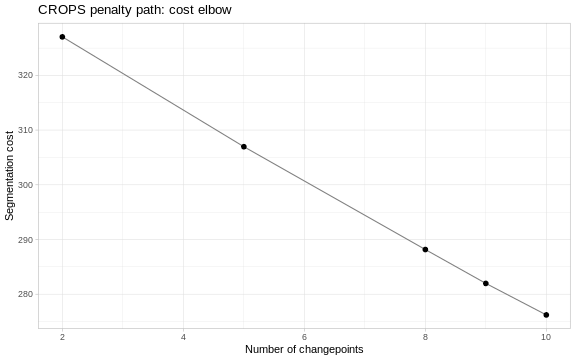

```r
autoplot(path)                          # the cost elbow
```

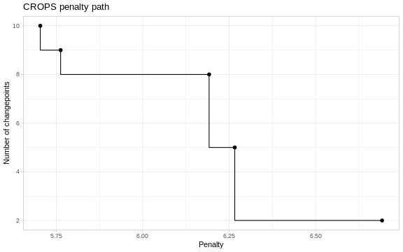

```r
autoplot(path, type = "path")           # changepoints vs penalty
```

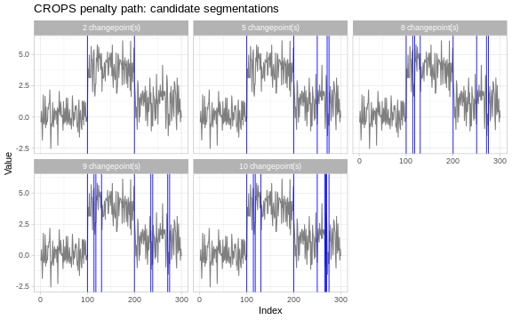

```r
autoplot(path, type = "segmentations")  # the candidate models themselves
```

# The visualisation layer

`autoplot()` renders any `ggcpt`. Options: `show_segments` (fitted segment means), `show_fit` (the engine’s own fitted signal, where provided; the nine engines `cpt_methods()` marks in its `fitted` column: SMUCE, HSMUCE, CPOP, bcp, BEAST, DeCAFS, segmented, mcp, bfast), `show_ci` (changepoint-location confidence intervals, where provided; the seven marked in its `ci` column: SMUCE, HSMUCE, strucchange, segmented, mcp, bfast, taylor; `nsp` is marked there too but reports a region, drawn by `show_regions`), `show_points`/`show_line`, an `index` for a date axis, and the `cptline_*` styling arguments (`cptline_color`, `cptline_alpha`, `cptline_type`, `cptline_linewidth`). Asking for an overlay the result cannot supply warns rather than failing silently.

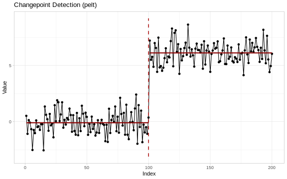

```r
autoplot(res, show_segments = TRUE, cptline_color = "firebrick",
         cptline_type = "dashed", cptline_linewidth = 0.8)
```

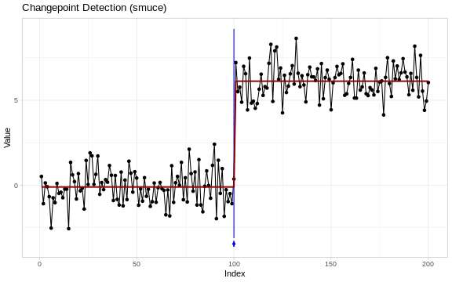

```r
autoplot(res_smuce, show_ci = TRUE, show_fit = TRUE)
```

Multivariate results facet automatically:

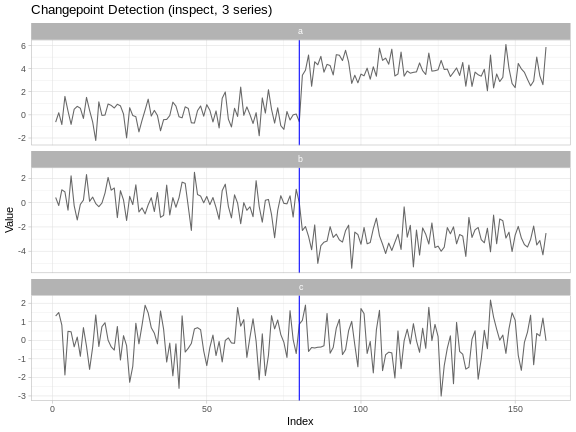

```r
autoplot(res_hd)
```

The composable layers work inside any ggplot pipeline: `geom_changepoint()` draws vertical rules, `geom_cpt_segment()` draws segment levels, `geom_cpt_ci()` draws horizontal interval whiskers, and `stat_changepoint()` runs detection *inside* the plot. `theme_ggcpt()` is a publication theme and `annotate_segments()` shades alternating segments.

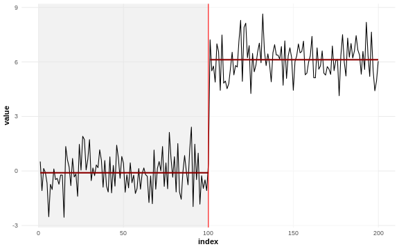

```r
cp_tbl <- tidy(res)
df <- data.frame(index = seq_along(x), value = x)

ggplot(df, aes(index, value)) +
  annotate_segments(cp = cp_tbl$cp, n = length(x)) +
  geom_line() +
  geom_changepoint(data = cp_tbl, aes(xintercept = cp), color = "red") +
  geom_cpt_segment(
    data = res$segments,
    aes(x = start, xend = end, y = param_estimate, yend = param_estimate),
    inherit.aes = FALSE, color = "darkred", linewidth = 1
  ) +
  theme_ggcpt()
```

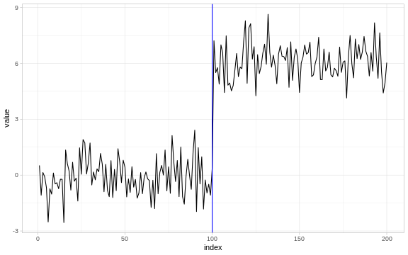

```r
ggplot(df, aes(index, value)) +
  geom_line() +
  stat_changepoint(method = "pelt", color = "blue")
```

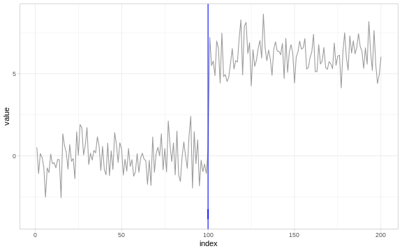

```r
ci_tbl <- tidy(res_smuce)
ci_tbl$y_pos <- min(x) - 1
ggplot(df, aes(index, value)) +
  geom_line(color = "grey60") +
  geom_cpt_ci(
    data = ci_tbl,
    aes(y = y_pos, xmin = ci_lower, xmax = ci_upper),
    width = 0.6, color = "blue", inherit.aes = FALSE
  ) +
  geom_changepoint(data = ci_tbl, aes(xintercept = cp), color = "blue")
```

`ggcptplot()` and `ggecpplot()` are the original one-call plots for the two classical engines:

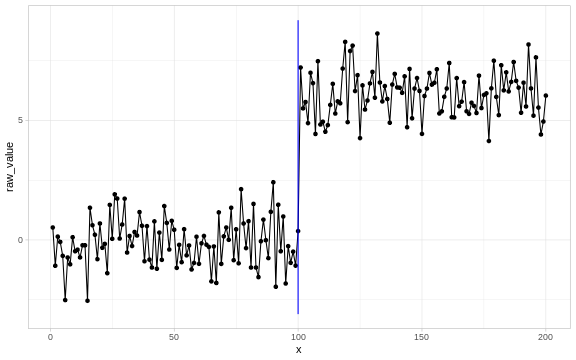

```r
ggcptplot(x, change_in = "mean", cp_method = "PELT")
```

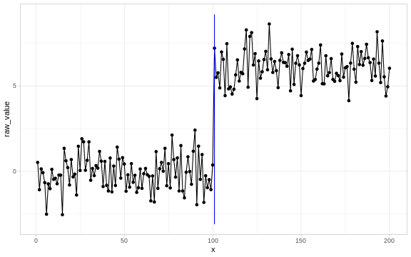

```r
ggecpplot(x, algorithm = "divisive", seed = 1)
```

The Bayesian engines get the field’s signature displays: `ggcpt_posterior()` shows the posterior mean over the series and the per-location changepoint probability (for `bcp` and BEAST results); `ggcpt_runlength()` shows the BOCPD run-length posterior as a heatmap.

```r
ggcpt_posterior(res_bcp)
```

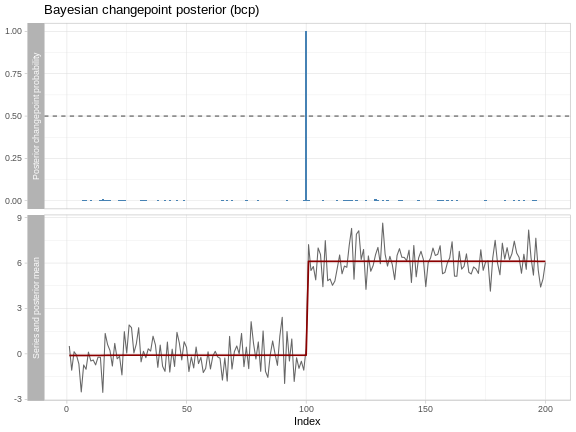

```r
ggcpt_runlength(res_bocpd)
```

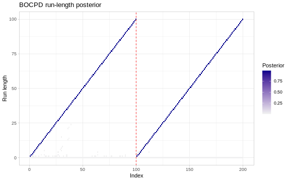

Finally, `ggcpt_interactive()` turns any result (or any ggplot built from one) into a `plotly` widget with values on hover. The widget itself is not embedded here, only its class:

```r
class(ggcpt_interactive(res))   # requires plotly
```

```
#> [1] "plotly"     "htmlwidget"
```

# Comparing methods

`ggcpt_compare()` runs several detectors on the same series and renders them faceted (default) or overlaid, honouring `future::plan()` for parallel execution; `ggcpt_compare_table()` returns the tidy union of the same runs. A method that finds nothing keeps its panel and contributes an `NA` row: “no changepoints” is a result, not a missing one.

```r
ggcpt_compare(x, methods = c("pelt", "binseg", "amoc"))
```

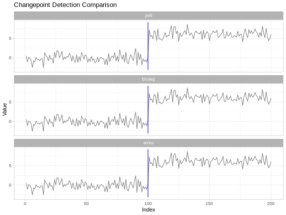

```r
ggcpt_compare(x, methods = c("pelt", "binseg"), layout = "overlay")
```

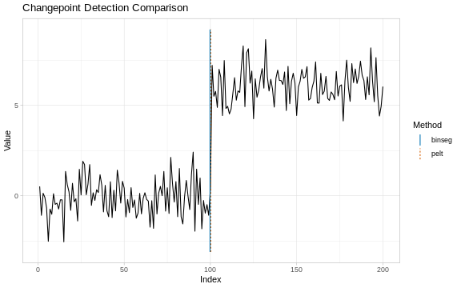

```r
ggcpt_compare_table(x, methods = c("pelt", "binseg", "amoc"))
```

```
#> # A tibble: 3 × 3
#>   method    cp cp_value
#>   <chr>  <int>    <dbl>
#> 1 pelt     100    0.369
#> 2 binseg   100    0.369
#> 3 amoc     100    0.369
```

# Batch detection and stability

`cpt_batch()` runs one detector over many series (matrix, data frame, or list of vectors), also under `future::plan()`, and returns a tidy `ggcpt_batch` tibble with list-columns for the per-series changepoints and the `ggcpt` objects themselves:

```r
set.seed(5103)
XB <- cbind(shifted = x, pure_noise = rnorm(200))
batch <- cpt_batch(XB, method = "pelt")
batch
```

```
#> ggcpt_batch (2 series, method: pelt)
#>
#> # A tibble: 2 × 2
#>   series     n_changepoints
#>   <chr>               <int>
#> 1 shifted                 1
#> 2 pure_noise              0
```

```r
tidy(batch)
```

```
#> # A tibble: 1 × 3
#>   series     cp cp_value
#>   <chr>   <int>    <dbl>
#> 1 shifted   100    0.369
```

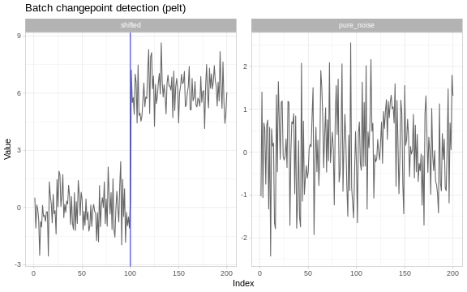

```r
autoplot(batch)
```

`cpt_stability()` quantifies how fragile a segmentation is: it resamples residuals within the fitted segments, re-runs the detector, and reports the re-detection frequency at every location, a model-agnostic confidence signal for engines with no native intervals:

```r
st <- cpt_stability(x, method = "pelt", B = 30, seed = 1)
st
```

```
#> ggcpt_stability (30 bootstrap replicates, method: pelt)
#>
#> Original changepoints and their re-detection frequency:
#> # A tibble: 1 × 2
#>      cp stability
#>   <int>     <dbl>
#> 1   100         1
```

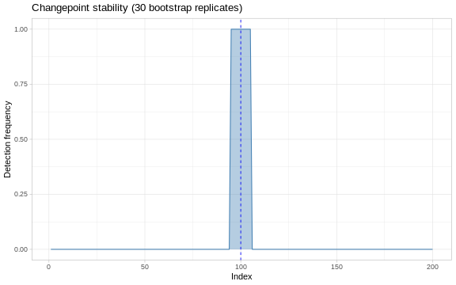

```r
autoplot(st)
```

# Evaluation against ground truth

`cpt_metrics()` scores predictions against a known truth: precision, recall and F1 under one-to-one matching, the covering metric and adjusted Rand index in the conventions of van den Burg and Williams (2020), Hausdorff distance, annotation error, and matched MAE/RMSE. `cpt_metrics_annotated()` averages over multiple annotators, and `ggcpt_eval()` draws the agreement (true positives, false positives, and misses):

```r
truth <- 100
pred <- tidy(res)$cp
cpt_metrics(pred, truth, n = length(x), margin = 5)
```

```
#> # A tibble: 1 × 12
#>       n n_pred n_truth precision recall    f1 covering hausdorff rand_index
#>   <int>  <int>   <int>     <dbl>  <dbl> <dbl>    <dbl>     <dbl>      <dbl>
#> 1   200      1       1         1      1     1        1         0          1
#> # ℹ 3 more variables: annotation_error <int>, mae_matched <dbl>,
#> #   rmse_matched <dbl>
```

```r
cpt_metrics_annotated(pred, list(100, 101, 99), n = length(x))
```

```
#> # A tibble: 1 × 7
#>       n n_annotators n_pred precision recall    f1 covering
#>   <int>        <int>  <int>     <dbl>  <dbl> <dbl>    <dbl>
#> 1   200            3      1         1      1     1    0.993
```

```r
ggcpt_eval(pred, truth, x, margin = 5)
```

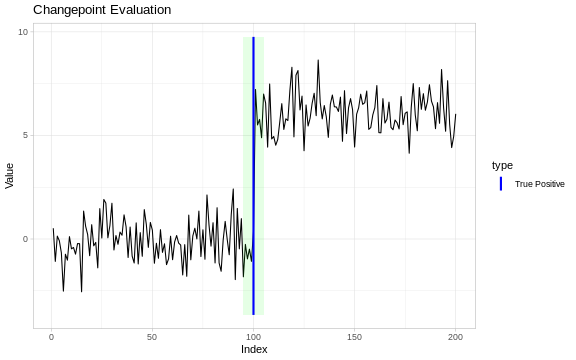

# Simulation and canonical signals

`cpt_simulate()` (alias `rcpt()`) generates series with known changepoints in mean, variance, both, or slope, under Gaussian, Student-t, AR(1), or random-walk noise; the truth travels with the data in the `true_changepoints` and `true_segments` attributes. Five canonical test signals from the literature ship ready-made: `signal_blocks()` (the Donoho-Johnstone blocks signal (Donoho and Johnstone 1994)), `signal_fms()`, `signal_mix()`, `signal_teeth()`, and `signal_stairs()`.

```r
sim <- cpt_simulate(300, changepoints = c(100, 200), change_in = "mean",
                    params = c(0, 5, 1), seed = 1)
attr(sim, "true_changepoints")
```

```
#> [1] 100 200
```

```r
sim2 <- rcpt(300, changepoints = 150, params = c(0, 3), seed = 2)  # the alias
attr(sim2, "true_changepoints")
```

```
#> [1] 150
```

```r
signals <- list(blocks = signal_blocks(1024, seed = 1),
                fms    = signal_fms(500, seed = 1),
                mix    = signal_mix(500, seed = 1),
                teeth  = signal_teeth(400, seed = 1),
                stairs = signal_stairs(500, seed = 1))
vapply(signals, function(s) length(attr(s, "true_changepoints")), integer(1))
```

```
#> blocks    fms    mix  teeth stairs
#>     11      7      5      3      9
```

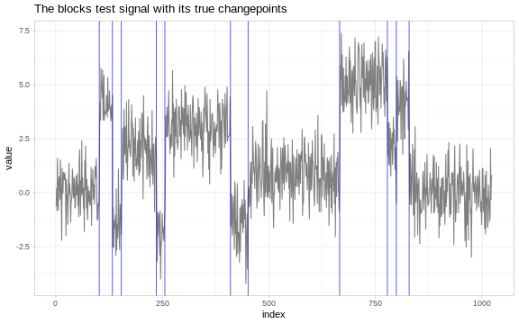

```r
blocks <- signals$blocks
ggplot(blocks, aes(index, value)) +
  geom_line(color = "grey50") +
  geom_vline(xintercept = attr(blocks, "true_changepoints"),
             color = "blue", linewidth = 0.3) +
  labs(title = "The blocks test signal with its true changepoints")
```

# Citing the methodology

`cpt_cite()` returns the verified reference(s) behind a result or a method name, so a write-up can cite the right paper without leaving R; called with no argument it returns the whole method-to-reference table.

```r
cpt_cite("pelt")
```

```
#> [pelt] Killick, R., Fearnhead, P. and Eckley, I. A. (2012). Optimal detection of changepoints with a linear computational cost. Journal of the American Statistical Association, 107(500), 1590-1598.
```

```r
cpt_cite(res)
```

```
#> [pelt] Killick, R., Fearnhead, P. and Eckley, I. A. (2012). Optimal detection of changepoints with a linear computational cost. Journal of the American Statistical Association, 107(500), 1590-1598.
```

# The 0.5.0 surface

The sections above are the 0.4.0 tour. What follows visits the rest of the exported surface, one example each; four companion vignettes develop these properly.

## Time indices

`cpt_detect(index = )` attaches a clock. Detection still runs on positions, because every engine assumes an equally spaced sequence, but `tidy()`, `augment()`, `autoplot()` and the reporting functions all speak in the user’s units. `as_cpt_series()` is the coercion underneath, and it accepts `ts`, `xts`, `zoo` and `tsibble` directly.

```r
dates <- as.Date("2020-01-01") + seq_along(x) - 1
dated <- cpt_detect(x, method = "pelt", index = dates)
tidy(dated)
```

```
#> # A tibble: 1 × 3
#>      cp cp_index   cp_value
#>   <int> <date>        <dbl>
#> 1   100 2020-04-09    0.369
```

```r
cpt_detect(data.frame(day = dates, v = x), y = v, index = day,
           method = "pelt")$changepoints$cp_index
```

```
#> [1] "2020-04-09"
```

`as_cpt_series()` is that coercion on its own, returning the values, the index, a label for the axis, and any seasonal frequency the input carried (which is how `cpt_detect(monthly_ts, method = "bfast")` fits at the right frequency instead of the wrapper’s default):

```r
str(as_cpt_series(x, index = dates), max.level = 1)
```

```
#> List of 4
#>  $ values     : num [1:200] 0.5206 -1.0797 0.1392 -0.0847 -0.6666 ...
#>  $ index      : Date[1:200], format: "2020-01-01" "2020-01-02" ...
#>  $ index_label: chr "Index"
#>  $ frequency  : NULL
```

```r
as_cpt_series(ts(x, start = c(2020, 1), frequency = 12))$index_label
```

```
#> [1] "Time"
```

```r
as_cpt_series(ts(x, start = c(2020, 1), frequency = 4))$frequency
```

```
#> [1] 4
```

## Inference

`nsp_wrapper()` returns significance regions, read with `cpt_regions()` and drawn by `geom_cpt_region()`. `cpt_confint()` unifies four interval routes; `cpt_test()` attaches a test and flags whether it is selection-adjusted.

```r
cpt_confint(res, method = "bootstrap", B = 30, seed = 1)
```

```
#> # A tibble: 1 × 6
#>      cp ci_lower ci_upper level source    n_replicates
#>   <int>    <int>    <int> <dbl> <chr>            <int>
#> 1   100      100      100  0.95 bootstrap           30
```

```r
suppressWarnings(cpt_test(res))[, c("cp", "estimate", "p_value",
                                    "selection_adjusted")]
```

```
#> # A tibble: 1 × 4
#>      cp estimate   p_value selection_adjusted
#>   <int>    <dbl>     <dbl> <lgl>
#> 1   100     6.22 1.61e-105 FALSE
```

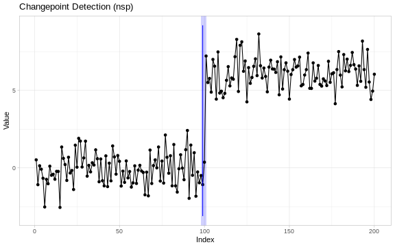

```r
autoplot(nsp_wrapper(x, M = 100, seed = 1))
```

## Selecting the number of changepoints

```r
sel <- cpt_select(x3, criterion = "bic", k_max = 6)
sel$k
```

```
#> [1] 2
```

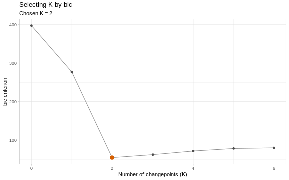

```r
autoplot(sel)
```

## Diagnostics

`cpt_influence()` and `cpt_leverage()` say which observation drives the answer; `cpt_sensitivity()` says which setting does; `cpt_statistic()`, `cpt_solution_path()` and `cpt_scale_space()` (with their `ggcpt_*()` plots, reachable from `autoplot(type = )`) say what the detector actually computed.

```r
inf <- cpt_influence(res, engine = "recompute", subset = seq(1, 200, by = 20))
head(cpt_leverage(inf), 3)
```

```
#> # A tibble: 3 × 5
#>   index delta_n_cp max_shift param_shift leverage
#>   <int>      <int>     <dbl>       <dbl>    <dbl>
#> 1   121          0         0      0.0180    1.75
#> 2   161          0         0      0.0130    0.832
#> 3   101          0         0      0.0111    0.484
```

```r
cpt_sensitivity(x, method = "pelt", over = list(penalty = c(4, 40)))$grid[, 1:2]
```

```
#> # A tibble: 2 × 2
#>   penalty  n_cp
#>     <dbl> <int>
#> 1       4     7
#> 2      40     1
```

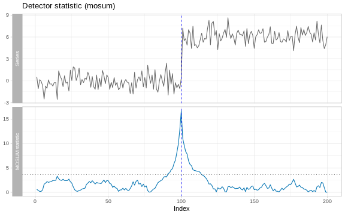

```r
autoplot(cpt_detect(x, method = "mosum"), type = "statistic")
```

## Supervised detection

```r
labs <- cpt_labels(c(80, 140), c(120, 190), c("one_change", "no_change"))
cpt_label_error(res, labs)[, c("start", "end", "change", "status")]
```

```
#> # A tibble: 2 × 4
#>   start   end change     status
#>   <int> <int> <chr>      <chr>
#> 1    80   120 one_change correct
#> 2   140   190 no_change  correct
```

`as_cpt_labels()` converts a plain ground-truth set into labels, `cpt_label_error_curve()` traces the errors across a penalty grid, and `cpt_learn_penalty()` fits a penalty from several labelled series; see `vignette("supervised", package = "ggchangepoint")`.

## Choosing and combining methods

```r
cpt_recommend(noise = "heavy")
```

```
#> Recommended methods for: univariate series, change in mean, heavy noise
#>
#> 1. cpm (cpm)
#>    why: handles change_in = "mean"; built for heavy noise
#> 2. ecp (ecp)
#>    why: handles change_in = "mean"; built for heavy noise
#> 3. kcp (kcpRS)
#>    why: handles change_in = "mean"; built for heavy noise
#> 4. np (changepoint.np)
#>    why: handles change_in = "mean"; built for heavy noise
#> 5. nsp (nsp)
#>    why: handles change_in = "mean"; built for heavy noise
#>
#> (31 further candidate(s); the full table is the return value.)
#>
#> Cite the method you use with cpt_cite(). Cross-check the choice with
#> cpt_consensus() and cpt_sensitivity().
```

```r
tidy(cpt_consensus(x3, methods = c("pelt", "binseg", "amoc")))
```

```
#> # A tibble: 2 × 5
#>      cp cp_value votes methods            spread
#>   <int>    <dbl> <int> <chr>               <int>
#> 1   100   -0.100     3 amoc, binseg, pelt      0
#> 2   200    2.90      2 binseg, pelt            0
```

## Communication

```r
cpt_annotate_events(dated,
                    data.frame(when = as.Date("2020-04-10"),
                               what = "policy change"))
```

```
#> ggcpt_events (tolerance 5 position(s))
#>   Changepoints explained by an event: 1
#>   Changepoints with no event:         0
#>   Events with no changepoint:         0
#>
#> Matched:
#> # A tibble: 1 × 6
#>      cp cp_index   event         event_value event_position distance
#>   <int> <date>     <chr>         <date>               <int>    <int>
#> 1   100 2020-04-09 policy change 2020-04-10             101        1
```

`cpt_report()` assembles the whole analysis into markdown, and `cpt_gt()` renders a publication table (falling back to a tibble, with a note, when `gt` is not installed):

```r
cpt_gt(res, title = "Detected changepoints")
```

Detected changepoints

1 changepoint(s) in mean over 200 observations; penalty MBIC

| # | Location | Value at change | Level before | Level after | Change |
| --- | --- | --- | --- | --- | --- |
| 1 | 100 | 0.369 | -0.098 | 6.122 | 6.22 |

`geom_cpt_event()` draws the events. `scale_colour_cpt()`, `scale_fill_cpt()`, `scale_linetype_cpt()`, `scale_fill_cpt_label()` and `scale_colour_cpt_label()` are the colour-vision-safe scales: the Okabe-Ito palette, plus a linetype scale so that colour is never the only channel carrying a distinction. All three at once, on the fitted segmentation:

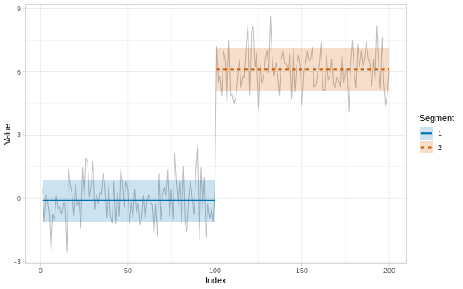

```r
aug <- augment(res)
ggplot(aug, aes(index, .fitted, colour = factor(seg_id),
                linetype = factor(seg_id))) +
  geom_line(aes(y = value), colour = "grey75", linetype = "solid") +
  geom_ribbon(aes(ymin = .fitted - 1, ymax = .fitted + 1,
                  fill = factor(seg_id)), alpha = 0.2, colour = NA) +
  geom_line(linewidth = 1) +
  scale_colour_cpt() + scale_fill_cpt() + scale_linetype_cpt() +
  labs(x = "Index", y = "Value", colour = "Segment", fill = "Segment",
       linetype = "Segment")
```

`theme_ggcpt()` is unchanged.

## Benchmarking

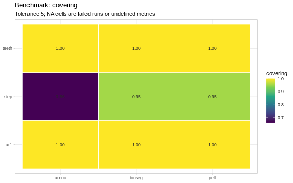

```r
bm <- cpt_benchmark(cpt_datasets(n = 200, seed = 1,
                                 names = c("step", "teeth", "ar1")),
                    methods = c("pelt", "binseg", "amoc"), progress = FALSE)
autoplot(bm)
```

```r
cpt_annotations(cpt_datasets(n = 200, names = "step"))
```

```
#> # A tibble: 2 × 3
#>   dataset annotator    cp
#>   <chr>   <chr>     <int>
#> 1 step    1            66
#> 2 step    1           133
```

`cpt_load_tcpd()` downloads and caches the Turing Change Point Dataset; it is not run here because it needs a network connection.

## Streaming

```r
set.seed(5104)
mon <- cpt_replay(c(rnorm(200), rnorm(200, 3)), method = "edetector")
alarms(mon)
```

[output not shown]

```r
cpt_delay(mon, truth = 200)
```

```
#> ggcpt_delay
#>   True changes:       1
#>   Detected:           1
#>   Mean delay:         2
#>   Median delay:       2
#>   False alarms:       2
#>   Average run length: 150
#>
#> # A tibble: 1 × 4
#>   truth alarm delay detected
#>   <int> <int> <dbl> <lgl>
#> 1   200   202     2 TRUE
```

`cpt_monitor()` and `cpt_update()` are the incremental form: `mon <- cpt_update(mon, new_obs)` as data arrive.

## Power and study design

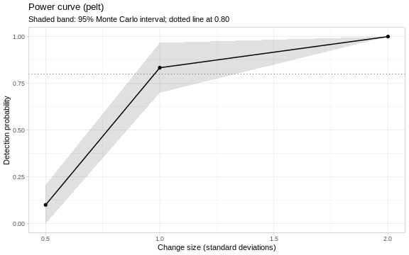

```r
pw <- cpt_power(n = 200, jump = c(0.5, 1, 2), n_sim = 30, seed = 1)
autoplot(pw)
```

`cpt_min_detectable()` inverts the curve: it bisects for the change size that reaches a target power, which is the number a pre-registration needs:

```r
cpt_min_detectable(n = 150, n_sim = 15, max_iter = 3, seed = 1)$jump
```

```
#> [1] 1.325
```

`cpt_scenarios()` builds the grid a simulation study varies over as data rather than as nested loops, so it can be inspected, filtered and passed straight to `cpt_benchmark()`:

```r
cpt_scenarios(n = c(200, 500), jump = c(1, 2), as_datasets = FALSE)
```

```
#> # A tibble: 4 × 7
#>       n  jump location noise change_in   rho scenario
#>   <int> <dbl>    <dbl> <chr> <chr>     <dbl> <chr>
#> 1   200     1      0.5 gauss mean          0 mean_n200_j1_gauss
#> 2   500     1      0.5 gauss mean          0 mean_n500_j1_gauss
#> 3   200     2      0.5 gauss mean          0 mean_n200_j2_gauss
#> 4   500     2      0.5 gauss mean          0 mean_n500_j2_gauss
```

## Extending

```r
fit_ext <- as_ggcpt(c(100), x, method = "external_detector")
glance(fit_ext)[, c("method", "n_changepoints")]
```

```
#> # A tibble: 1 × 2
#>   method            n_changepoints
#>   <chr>                      <int>
#> 1 external_detector              1
```

```r
cpt_register_method("biggest_jump",
                    fn = function(x, ...) which.max(abs(diff(x))),
                    engine = "example")
cpt_detect(x, method = "biggest_jump")$changepoints$cp
```

```
#> [1] 100
```

```r
subset(cpt_methods(), status == "registered")[, c("method", "engine")]
```

```
#> # A tibble: 1 × 2
#>   method       engine
#>   <chr>        <chr>
#> 1 biggest_jump example
```

```r
cpt_registered_methods()
```

```
#> # A tibble: 1 × 4
#>   method       change_in engine  has_citation
#>   <chr>        <chr>     <chr>   <lgl>
#> 1 biggest_jump mean      example FALSE
```

```r
cpt_unregister_method("biggest_jump")
```

`cpt_install_engines()` installs a family of engines at a time:

```r
cpt_install_engines("bayesian", dry_run = TRUE)[, c("package",
                                                    "installed_before")]
```

```
#> # A tibble: 4 × 2
#>   package installed_before
#>   <chr>   <lgl>
#> 1 bcp     TRUE
#> 2 ocp     TRUE
#> 3 Rbeast  TRUE
#> 4 mcp     FALSE
```

# Closing note

This tour visited every exported function in the package. For the framework’s design, the mathematics of the wrapped methods, and worked analyses, see `vignette("introduction", package = "ggchangepoint")`; for method comparison and accuracy evaluation in depth, see `vignette("comparison", package = "ggchangepoint")`; and for the 0.5.0 additions in depth, see `vignette("inference")`, `vignette("supervised")`, `vignette("extending")` and `vignette("monitoring")`.

# References

Adams, Ryan Prescott, and David JC MacKay. 2007. “Bayesian Online Changepoint Detection.” *arXiv Preprint arXiv:0710.3742*.

Anastasiou, Andreas, and Piotr Fryzlewicz. 2022. “Detecting Multiple Generalized Change-Points by Isolating Single Ones.” *Metrika* 85: 141–74. https://doi.org/10.1007/s00184-021-00821-6.

Arlot, Sylvain, Alain Celisse, and Zaid Harchaoui. 2019. “A Kernel Multiple Change-Point Algorithm via Model Selection.” *Journal of Machine Learning Research* 20 (162): 1–56.

Bai, Jushan, and Pierre Perron. 1998. “Estimating and Testing Linear Models with Multiple Structural Changes.” *Econometrica* 66 (1): 47–78.

———. 2003. “Computation and Analysis of Multiple Structural Change Models.” *Journal of Applied Econometrics* 18 (1): 1–22.

Baranowski, Rafał, Yining Chen, and Piotr Fryzlewicz. 2019. “Narrowest-over-Threshold Detection of Multiple Change Points and Change-Point-Like Features.” *Journal of the Royal Statistical Society Series B* 81 (3): 649–72. https://doi.org/10.1111/rssb.12322.

Barry, Daniel, and John A Hartigan. 1993. “A Bayesian Analysis for Change Point Problems.” *Journal of the American Statistical Association* 88 (421): 309–19.

Beaulieu, Claudie, and Rebecca Killick. 2018. “Distinguishing Trends and Shifts from Memory in Climate Data.” *Journal of Climate* 31 (23): 9519–43.

Cabrieto, Jedelyn, Janne Adolf, Francis Tuerlinckx, Peter Kuppens, and Eva Ceulemans. 2018. “Detecting Long-Lived Autodependency Changes in a Multivariate System via Change Point Detection and Regime Switching Models.” *Scientific Reports* 8: 15637.

Chen, Yudong, Tengyao Wang, and Richard J Samworth. 2022. “High-Dimensional, Multiscale Online Changepoint Detection.” *Journal of the Royal Statistical Society: Series B* 84 (1): 234–66.

Donoho, David L, and John M Johnstone. 1994. “Ideal Spatial Adaptation by Wavelet Shrinkage.” *Biometrika* 81 (3): 425–55. https://doi.org/10.1093/biomet/81.3.425.

Eichinger, Birte, and Claudia Kirch. 2018. “A MOSUM Procedure for the Estimation of Multiple Random Change Points.” *Bernoulli* 24 (1): 526–64. https://doi.org/10.3150/16-BEJ887.

Erdman, Chandra, and John W Emerson. 2007. “Bcp: An r Package for Performing a Bayesian Analysis of Change Point Problems.” *Journal of Statistical Software* 23 (3): 1–13.

Fearnhead, Paul, and Daniel Grose. 2024. “Cpop: Detecting Changes in Piecewise-Linear Signals.” *Journal of Statistical Software* 109 (7): 1–30.

Fearnhead, Paul, Robert Maidstone, and Adam Letchford. 2019. “Detecting Changes in Slope with an L0 Penalty.” *Journal of Computational and Graphical Statistics* 28 (2): 265–75.

Frick, Klaus, Axel Munk, and Hannes Sieling. 2014. “Multiscale Change Point Inference.” *Journal of the Royal Statistical Society: Series B* 76 (3): 495–580.

Fryzlewicz, Piotr. 2014. “Wild Binary Segmentation for Multiple Change-Point Detection.” *The Annals of Statistics* 42 (6): 2243–81. https://doi.org/10.1214/14-AOS1245.

———. 2018. “Tail-Greedy Bottom-up Data Decompositions and Fast Multiple Change-Point Detection.” *The Annals of Statistics* 46 (6B): 3390–3421.

———. 2020. “Detecting Multiple Change-Point Features via Narrowest-over-Threshold.” *Journal of the Royal Statistical Society Series B* 82 (5): 1377–1418.

Grundy, Thomas, Rebecca Killick, and Gueorgui Mihaylov. 2020. “High-Dimensional Changepoint Detection via a Geometrically Inspired Mapping.” *Statistics and Computing* 30: 1155–66.

Haynes, Kaylea, Paul Fearnhead, and Idris A Eckley. 2017. “A Computationally Efficient Nonparametric Approach for Changepoint Detection.” *Statistics and Computing* 27 (5): 1313–29. https://doi.org/10.1007/s11222-016-9687-5.

James, Nicholas A, and David S Matteson. 2014. “Ecp: An R Package for Nonparametric Multiple Change Point Analysis of Multivariate Data.” *Journal of Statistical Software* 62 (7): 1–25. https://doi.org/10.18637/jss.v062.i07.

Killick, Rebecca, and Idris Eckley. 2014. “Changepoint: An R Package for Changepoint Analysis.” *Journal of Statistical Software* 58 (3): 1–19. https://doi.org/10.18637/jss.v058.i03.

Killick, Rebecca, Paul Fearnhead, and Idris A Eckley. 2012. “Optimal Detection of Changepoints with a Linear Computational Cost.” *Journal of the American Statistical Association* 107 (500): 1590–98. https://doi.org/10.1080/01621459.2012.737745.

Li, Xingchi, and Xianyang Zhang. 2024. “Fastcpd: Fast Change Point Detection in r.” *arXiv Preprint arXiv:2404.05933*.

Maidstone, Robert, Toby Hocking, Guillem Rigaill, and Paul Fearnhead. 2017. “On Optimal Multiple Changepoint Algorithms for Large Data.” *Statistics and Computing* 27 (2): 519–33. https://doi.org/10.1007/s11222-016-9636-3.

Matteson, David S, and Nicholas A James. 2014. “A Nonparametric Approach for Multiple Change Point Analysis of Multivariate Data.” *Journal of the American Statistical Association* 109 (505): 334–45.

McGonigle, Euan T, and Haeran Cho. 2025. “Nonparametric Data Segmentation in Multivariate Time Series via Joint Characteristic Functions.” *Biometrika* 112 (2): asaf024.

Muggeo, Vito MR. 2003. “Estimating Regression Models with Unknown Break-Points.” *Statistics in Medicine* 22 (19): 3055–71.

———. 2008. “Segmented: An r Package to Fit Regression Models with Broken-Line Relationships.” *R News* 8 (1): 20–25.

Pein, Florian, Hannes Sieling, and Axel Munk. 2017. “Heterogeneous Change Point Inference.” *Journal of the Royal Statistical Society: Series B* 79 (4): 1207–27.

Robinson, David. 2017. “Broom: An R Package for Converting Statistical Analysis Objects into Tidy Data Frames.” *Journal of Open Source Software* 2 (19): 401. https://doi.org/10.21105/joss.00401.

Romano, Gaetano, Guillem Rigaill, Vincent Runge, and Paul Fearnhead. 2022. “Detecting Abrupt Changes in the Presence of Local Fluctuations and Autocorrelated Noise.” *Journal of the American Statistical Association* 117 (540): 2147–62.

Ross, Gordon J. 2015. “Parametric and Nonparametric Sequential Change Detection in r: The Cpm Package.” *Journal of Statistical Software* 66 (3): 1–20.

van den Burg, Gerrit J J, and Christopher K I Williams. 2020. “An Evaluation of Change Point Detection Algorithms.” *arXiv Preprint arXiv:2003.06222*. https://doi.org/10.48550/arXiv.2003.06222.

Wang, Tengyao, and Richard J Samworth. 2018. “High Dimensional Change Point Estimation via Sparse Projection.” *Journal of the Royal Statistical Society: Series B* 80 (1): 57–83.

Wickham, Hadley. 2016. *Ggplot2: Elegant Graphics for Data Analysis*. Springer. https://doi.org/10.1007/978-3-319-24277-4.

Zeileis, Achim, Friedrich Leisch, Kurt Hornik, and Christian Kleiber. 2002. “Strucchange: An r Package for Testing for Structural Change in Linear Regression Models.” *Journal of Statistical Software* 7 (2): 1–38.

Zhao, Kaiguang, Michael A Wulder, Tongxi Hu, Ryan Bright, Qiusheng Wu, Haiming Qin, Yang Li, et al. 2019. “Detecting Change-Point, Trend, and Seasonality in Satellite Time Series Data to Track Abrupt Changes and Nonlinear Dynamics: A Bayesian Ensemble Algorithm.” *Remote Sensing of Environment* 232: 111181.

Zhao, Zifeng, Feiyu Jiang, and Xiaofeng Shao. 2022. “Segmenting Time Series via Self-Normalisation.” *Journal of the Royal Statistical Society: Series B* 84 (5): 1699–1725.